# Lab 1: Intro to R

Jaime Rodriguez

2022-09-03

```r
library(tidyverse)
library(openintro)
```

## Data

```r
arbuthnot
```

```
## # A tibble: 82 × 3
##     year  boys girls
##    <int> <int> <int>
##  1  1629  5218  4683
##  2  1630  4858  4457
##  3  1631  4422  4102
##  4  1632  4994  4590
##  5  1633  5158  4839
##  6  1634  5035  4820
##  7  1635  5106  4928
##  8  1636  4917  4605
##  9  1637  4703  4457
## 10  1638  5359  4952
## # … with 72 more rows
```

### Exercise 1

```r
arbuthnot$girls
```

```
##  [1] 4683 4457 4102 4590 4839 4820 4928 4605 4457 4952 4784 5332 5200 4910 4617
## [16] 3997 3919 3395 3536 3181 2746 2722 2840 2908 2959 3179 3349 3382 3289 3013
## [31] 2781 3247 4107 4803 4881 5681 4858 4319 5322 5560 5829 5719 6061 6120 5822
## [46] 5738 5717 5847 6203 6033 6041 6299 6533 6744 7158 7127 7246 7119 7214 7101
## [61] 7167 7302 7392 7316 7483 6647 6713 7229 7767 7626 7452 7061 7514 7656 7683
## [76] 5738 7779 7417 7687 7623 7380 7288
```

#### Data Visualization

Practice

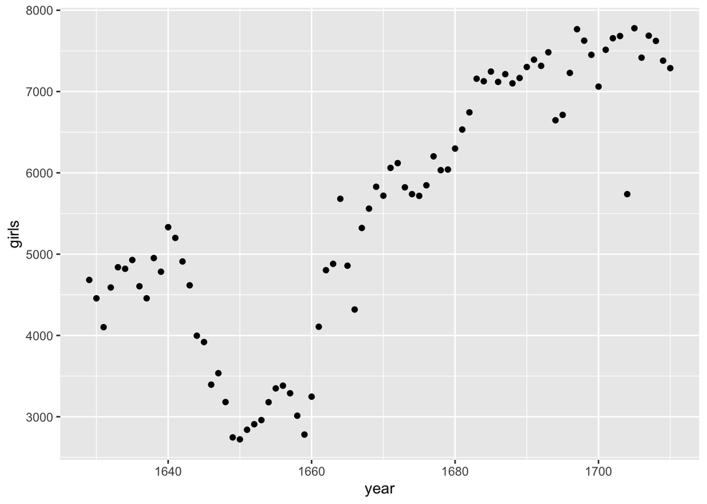

```r
ggplot(data = arbuthnot, aes(x = year, y = girls)) +
  geom_point()
```

With ggplot(): * The first argument is always the name of the dataset you wish to use for plotting. * Next, you provide the variables from the dataset to be assigned to different aesthetic elements of the plot, such as the x and the y axes. * adding a + at the end of the line, to indicate that you are adding a layer * then specify the geometric object to be used to create the plot.

?ggplot provides documentation for a function

Example with geom_line()

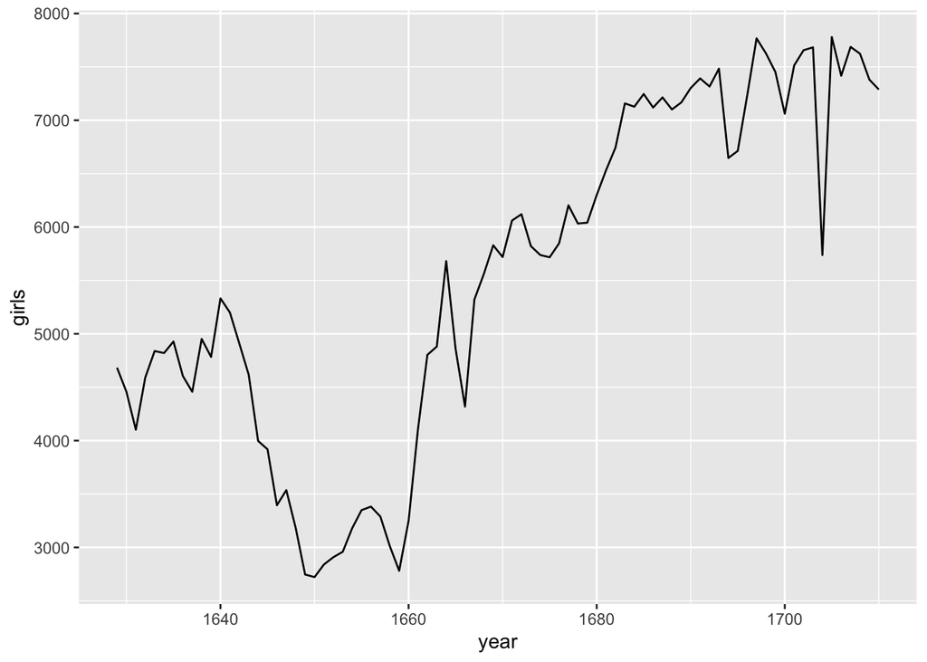

```r
ggplot(data = arbuthnot, aes(x = year, y = girls)) +
  geom_line()
```

### Exercise 2

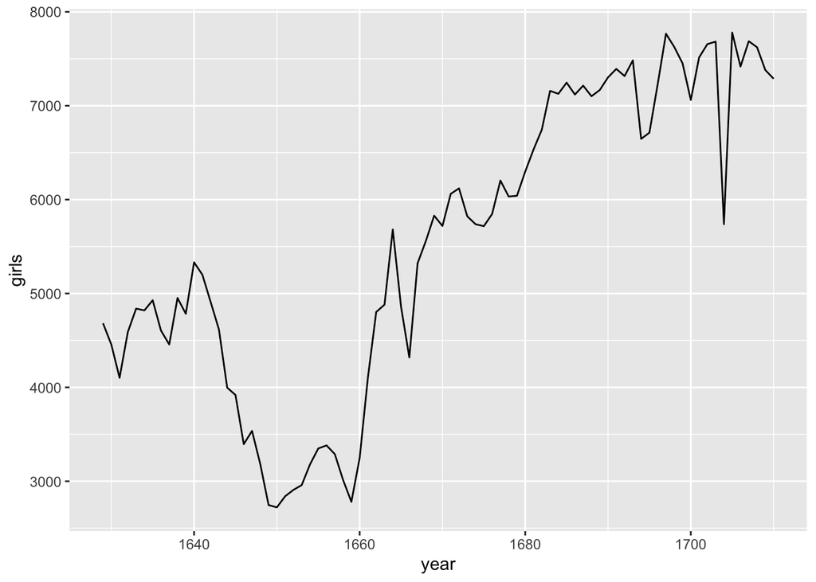

```r
ggplot(data = arbuthnot, aes(x = year, y = girls)) +
  geom_line()
```

#### R as a big calculator

Simple calculations

```r
5218 + 4683
```

```
## [1] 9901
```

```r
arbuthnot$boys + arbuthnot$girls
```

```
##  [1]  9901  9315  8524  9584  9997  9855 10034  9522  9160 10311 10150 10850
## [13] 10670 10370  9410  8104  7966  7163  7332  6544  5825  5612  6071  6128
## [25]  6155  6620  7004  7050  6685  6170  5990  6971  8855 10019 10292 11722
## [37]  9972  8997 10938 11633 12335 11997 12510 12563 11895 11851 11775 12399
## [49] 12626 12601 12288 12847 13355 13653 14735 14702 14730 14694 14951 14588
## [61] 14771 15211 15054 14918 15159 13632 13976 14861 15829 16052 15363 14639
## [73] 15616 15687 15448 11851 16145 15369 16066 15862 15220 14928
```

#### Adding a new variable to the data frame

Add total column to data

```r
arbuthnot <- arbuthnot %>%
  mutate(total = boys + girls)
```

Add boy to girl ratio column

```r
arbuthnot <- arbuthnot %>%
  mutate(boy_to_girl_ratio = boys / girls)
```

Add boy ratio column

```r
arbuthnot <- arbuthnot %>%
  mutate(boy_ratio = boys / total)
```

### Exercise 3

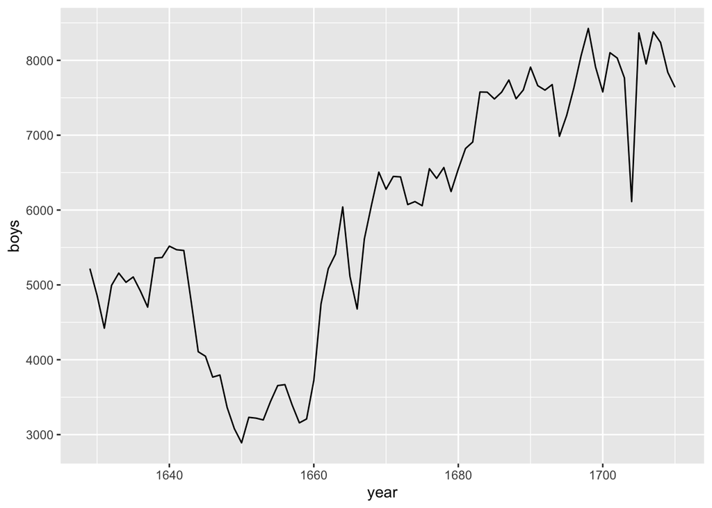

```r
ggplot(data = arbuthnot, aes(x = year, y = boys)) +
  geom_line()
```

#### More practice

see min and max values

```r
arbuthnot %>%
  summarize(min = min(boys),
            max = max(boys)
            )
```

```
## # A tibble: 1 × 2
##     min   max
##   <int> <int>
## 1  2890  8426
```

### Exercise 4

Data includes years from 1940 to 2002. 63 rows and 3 columns (year, boys, girls)

```r
present
```

```
## # A tibble: 63 × 3
##     year    boys   girls
##    <dbl>   <dbl>   <dbl>
##  1  1940 1211684 1148715
##  2  1941 1289734 1223693
##  3  1942 1444365 1364631
##  4  1943 1508959 1427901
##  5  1944 1435301 1359499
##  6  1945 1404587 1330869
##  7  1946 1691220 1597452
##  8  1947 1899876 1800064
##  9  1948 1813852 1721216
## 10  1949 1826352 1733177
## # … with 53 more rows
```

```r
present %>%
  summarize(beggining = min(year),
            ending = max(year)
            )
```

```
## # A tibble: 1 × 2
##   beggining ending
##       <dbl>  <dbl>
## 1      1940   2002
```

### Exercise 5

Ratio shows Arbuthnot numbers were much smaller but magnitude are mildly similar

```r
present <- present %>%
  mutate(total = boys + girls)
```

```r
present <- present %>%
  mutate(total_ratio = arbuthnot$total[c(1:63)] / present$total[c(1:63)])
```

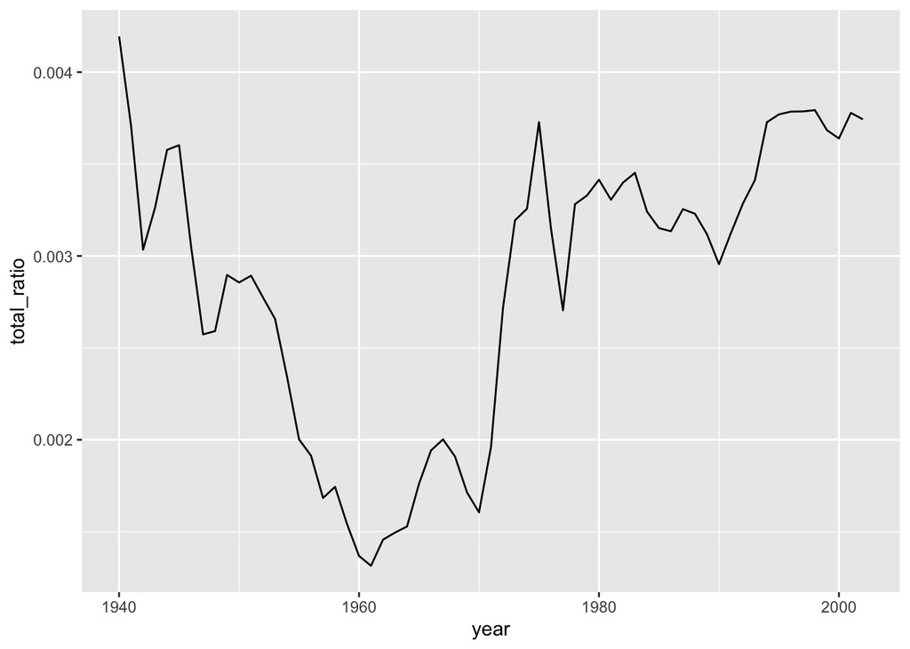

```r
ggplot(data = present, aes(x = year, y = total_ratio)) +
  geom_line()
```

### Exercise 6

Data shows somewhat similar results. Does show growth over time. However there were more stark declines within that growth.

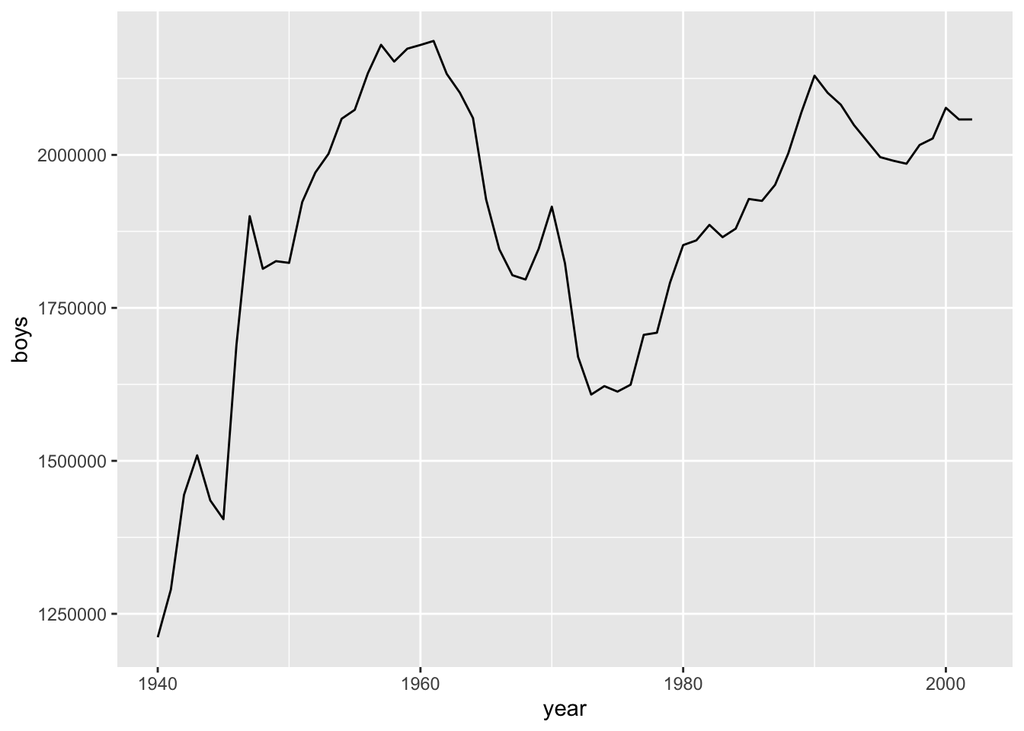

```r
ggplot(data = present, aes(x = year, y = boys)) +
  geom_line()
```

### Exercise 7

1961

```r
present %>%
  arrange(desc(total))
```

```
## # A tibble: 63 × 5
##     year    boys   girls   total total_ratio
##    <dbl>   <dbl>   <dbl>   <dbl>       <dbl>
##  1  1961 2186274 2082052 4268326     0.00131
##  2  1960 2179708 2078142 4257850     0.00137
##  3  1957 2179960 2074824 4254784     0.00168
##  4  1959 2173638 2071158 4244796     0.00154
##  5  1958 2152546 2051266 4203812     0.00174
##  6  1962 2132466 2034896 4167362     0.00146
##  7  1956 2133588 2029502 4163090     0.00191
##  8  1990 2129495 2028717 4158212     0.00296
##  9  1991 2101518 2009389 4110907     0.00313
## 10  1963 2101632 1996388 4098020     0.00150
## # … with 53 more rows
```